# compstatsR session 1: profiling and low-hanging fruit

30 October 2025

## plan

This presentation will loosely follow Ross (2013), a [blog post on speeding up R code](http://www.noamross.net/blog/2013/4/25/faster-talk.html)

- why optimize?
- alternative computing platforms
- benchmarking and scaling
- profiling
- low-hanging fruit
  - vectorization
  - not growing objects
  - compiling R code
  - better linear algebra packages

## not (or mostly not) covering

- workflows and version control (see [Software Carpentry](http://software-carpentry.org/))
- Unix shell (see [Software Carpentry](http://software-carpentry.org/), SHARCnet webinars)
- data munging and management (see [Data Carpentry](http://www.datacarpentry.org))

## prerequisites

- basic knowledge of R  
  (know what a data frame and a `for` loop are)
- intermediate comp stats knowledge  
  (e.g. Newton-Raphson, expectation-maximization)

## is it necessary?

> premature optimization is the root of all evil (or at least most of it) in programming ([Donald Knuth](https://en.wikiquote.org/wiki/Donald_Knuth))

> **Uwe’s Maxim**: Computers are cheap, and thinking hurts. (Burns 2012)
- how long will it take?
- how much do you really need to compute?
  - how many bootstrap runs?
  - how many MCMC samples?
  - how many parameter values?

You should be able to justify these decisions in any case!

## running somewhere else

- laptops are not made for serious computation
- notes on desktop keyboards are annoying

**instead:**

- math servers
- desktop machine, in background
- SHARCnet
- cloud services (e.g. Amazon web services)

[figure not shown]

[source](https://web.archive.org/web/20150801003102/https://www.zdnet.com/pictures/weird-tech-12-geeky-uses-for-technology/12/)

## how long will it take? scaling

qualitative analysis: scaling of run time/memory requirements with

- dimension
- number of observations
- number of groups (for multilevel models)
- number of parameters
- … etc.

Use *small* runs (large enough for stability, e.g. >1 min) to estimate, scale up

## how long will it take? benchmarking

- test alternative versions of code to compare performance
- useful for snippets that you’re going to put into larger code
- ([thousands of examples on StackOverflow](http://stackoverflow.com/search?q=%5Br%5D+benchmark))
- super-basic: built-in `system.time()`
- R packages: `rbenchmark`, `microbenchmark`, `bench`

## benchmarking example

```r
set.seed(101)
n <- 100000; p <- 10
X <- matrix(rnorm(n*p),ncol=p); y <- rnorm(n)
naive <- function() c(solve(t(X)%*%X)%*%t(X)%*%y)
smart <- function() unname(coef(lm.fit(X,y)))
all.equal(naive(), smart())  ## check equivalence
```

```
## [1] TRUE
```

```r
bm <- function(...) {
  bench::mark(...) %>%
    dplyr::select(expression, median, `itr/sec`, mem_alloc) %>%
    mutate(rel_speed = min(`itr/sec`)/`itr/sec`, .after = `itr/sec`) %>%
    mutate(rel_mem = as.numeric(mem_alloc/min(mem_alloc)),
           .after = mem_alloc) %>%
    arrange(rel_speed)
}
```

## profiling

- `Rprof` is the basic machine for profiling
  - `Rprof()` in code outputs profiling information to file
  - `R CMD Rprof <filename>` analyzes profiling information
- The Writing R Extensions document has a [Tidying and profiling R code](https://cran.r-project.org/doc/manuals/r-release/R-exts.html#Tidying-and-profiling-R-code) section
- the [profvis package](https://rstudio.github.io/profvis/) provides a prettier wrapper
- … also [aprof package](https://CRAN.R-project.org/package=aprof) …

## profiling: zero-inflated mixed model example

```r
source("R/zipme.R")  ## get zipme function
load("data/Owls.rda")   ## get Owls data
library(profvis)
library(lme4)
profvis(z1 <- zipme(cformula=SiblingNegotiation~
                (FoodTreatment+ArrivalTime)*SexParent+
                offset(logBroodSize)+(1|Nest),
            zformula=z ~ 1,
            data=Owls,maxitr=20,tol=1e-6,
            verbose=FALSE))
```

## profiling: HIV model example

Go to R/HIV_prof.R …

## low-hanging fruit

## low-hanging fruit

- Common performance issues
- Form good R coding habits
- Many ideas from Burns (2012) (“If you are using R and you think you’re in hell, this is a map for you”)

[figure not shown]

## growing objects (Inferno, circle #2)

- building up objects bit by bit is *super*-expensive
- if `i>length(y)`, setting `y[i]` will extend the vector
- growing data frames is even worse
- use `numeric(n)` to pre-allocate vectors
- `data.frame(x=numeric(n),...)`
- or: construct a list of data frames and `do.call(rbind,dfList)` (or `dplyr::bind_rows()`) to put them together

## growing objects: benchmark

```r
n <- 1e4
y <- 1
growing <- function() { for (i in 1:n) y[i] <- i; y }
vec2 <- function() { y <- numeric(n); y <- 1:n; y }
vec <- function() { y <- 1:n; y }
bm(growing(),vec(), vec2())
```

```
## # A tibble: 3 × 6
##   expression   median `itr/sec` rel_speed mem_alloc rel_mem
##   <bch:expr> <bch:tm>     <dbl>     <dbl> <bch:byt>   <dbl>
## 1 vec()      371.02ns  1894933.  0.000277        0B     NaN
## 2 vec2()       8.04µs    47939.  0.0110     78.17KB     Inf
## 3 growing()    1.83ms      525.  1           1.68MB     Inf
```

## vectorization (Inferno, circle #3)

- Sequential operations in R are expensive
- Every function call counts
- Use *vectorized* operations whenever possible
- `rowMeans()`, `colMeans()`
- Also: linear algebra (matrix products, Kronecker products, …)

```r
y <- numeric(n); x <- 1:n
nonvec <- function() { for (i in 1:n) y[i] <- 2*x[i]; y }
vec <- function() y <- 2*x
bm(nonvec(),vec())
```

```
## # A tibble: 2 × 6
##   expression   median `itr/sec` rel_speed mem_alloc rel_mem
##   <bch:expr> <bch:tm>     <dbl>     <dbl> <bch:byt>   <dbl>
## 1 vec()        10.4µs    93900.   0.00920   117.3KB    1.19
## 2 nonvec()     1.15ms      864.   1          98.4KB    1
```

## vectorization

Suppose we want to compute the means of `n1` sets of `n2` standard Normal deviates (R/vecrand.R): `source("R/vecrand.R")`

```r
f1 <-
function (n1 = 1000, n2 = 1000)
{
    res <- c()
    for (i in 1:n1) {
        x <- c()
        for (j in 1:n2) {
            x <- c(x, rnorm(1))
        }
        res <- c(res, mean(x))
    }
    return(res)
}
```

## double loop, no growing

```r
f2 <-
function (n1 = 1000, n2 = 1000)
{
    res <- numeric(n1)
    for (i in 1:n1) {
        x <- numeric(n2)
        for (j in 1:n2) {
            x[j] <- rnorm(1)
        }
        res[i] <- mean(x)
    }
    return(res)
}
```

## better versions

```r
f3 <-
function (n1 = 1000, n2 = 1000)
{
    res <- numeric(n1)
    for (i in 1:n1) {
        res[i] <- mean(rnorm(n2))
    }
    return(res)
}
```

```r
f4 <-
function (n1 = 1000, n2 = 1000)
{
    res <- matrix(rnorm(n1 * n2), nrow = n1)
    return(rowMeans(res))
}
```

## benchmark (100x100)

```r
bm(growing=f1(100,100),
   double_loop=f2(100,100),
   single_loop=f3(100,100),
   matrix=f4(100,100),
   iterations=50,
   check = FALSE)
```

```
## # A tibble: 4 × 6
##   expression    median `itr/sec` rel_speed mem_alloc rel_mem
##   <bch:expr>  <bch:tm>     <dbl>     <dbl> <bch:byt>   <dbl>
## 1 matrix       365.9µs    2437.     0.0363  157.17KB    1.47
## 2 single_loop    744µs    1344.     0.0658  106.88KB    1
## 3 double_loop    8.2ms     122.     0.725   121.55KB    1.14
## 4 growing       11.3ms      88.4    1         4.21MB   40.4
```

## a small surprise

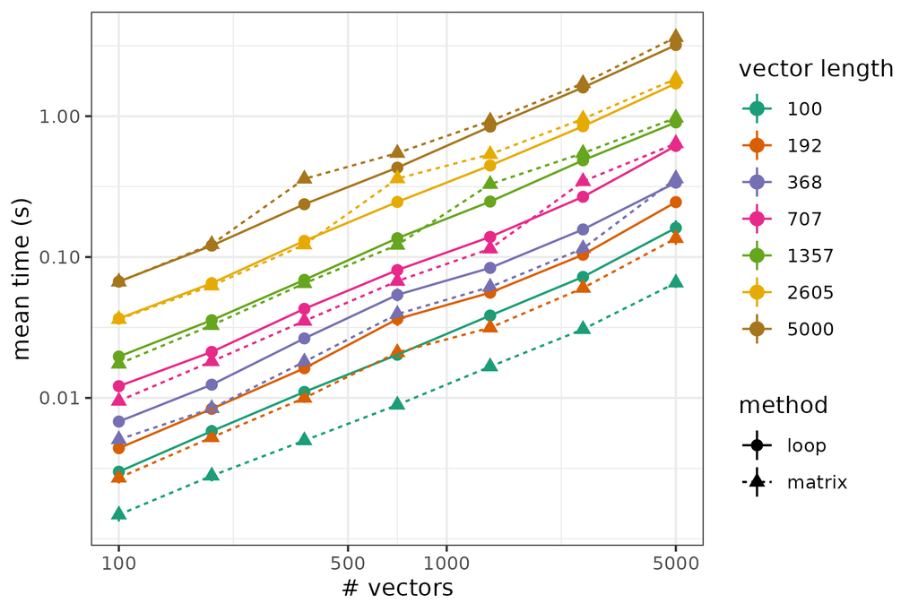

## another example (Visser et al. 2015)

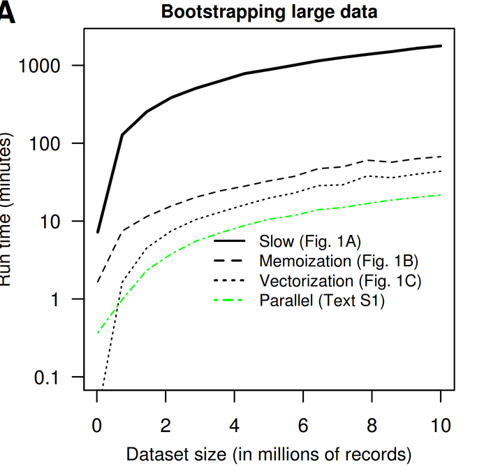

## over-vectorizing (Inferno, circle #4)

- sometimes you really can’t vectorize
- e.g. iterative computations
- difference between `for` and `*apply` (and `purrr::map`) is semantic
- use what you can understand!

> Everyone knows that debugging is twice as hard as writing a program in the first place. So if you’re as clever as you can be when you write it, how will you ever debug it? [Brian Kernighan](https://en.wikiquote.org/wiki/Brian_Kernighan)

## a few more tricks

- compilation

```r
library(compiler)
cmpfun <- compile(fn)
```

- use simpler data structures (`matrix` faster than `data.frame`)
- use the guts of a function to skip data-checking steps: e.g. `lm` vs `lm.fit` vs `.lm.fit`

## faster machinery

- faster linear algebra libraries (Eddelbuettel 2013)
- [Microsoft R](https://mran.revolutionanalytics.com/download/#download)

## use better packages

- Task Views ([CRAN](https://cran.r-project.org/web/views/), [alternate view](http://www.maths.lancs.ac.uk/~rowlings/R/TaskViews/))
- `sos::findFn()` (full-text search of CRAN)
- the [tidyverse](https://cran.r-project.org/web/packages/tidyverse/index.html)
  - mostly stylistic
  - pipe syntax `%>%`
  - faster operations on data

## asking for help (Inferno #9)

- include a minimal [reproducible example](http://stackoverflow.com/questions/5963269/how-to-make-a-great-r-reproducible-example)
- include appropriate context (goal, packages, versions, platform)
- be polite, without groveling
- be specific: say what’s not working
- say what you’ve tried/where you’ve looked
- don’t cross-post
- `d-r-users@mcmaster.ca`
- [R mailing lists](https://www.r-project.org/mail.html)
- [StackOverflow [r] tag](http://stackoverflow.com/questions/tagged/r?filter=all&sort=active)

> Getting flamed for asking dumb questions on a public mailing list is all part of growing up and being a man/woman. (Michael Watson, `fortunes` package)

## additional topics

- general-purpose nonlinear minimization
  - derivative vs derivative-free
  - noisy surfaces
  - `optim`, `nloptr` package
  - [optimization task view](https://cran.r-project.org/web/views/Optimization.html); Nash (2014)
- memoi[sz]ation ([memoise package](https://CRAN.R-project.org/package=memoise))
- code style [DRY; write functions (Inferno circle #5, Wilson et al. (2014)]

## References

Burns, Patrick. 2012. *The R Inferno*. Lulu.com. http://www.burns-stat.com/pages/Tutor/R_inferno.pdf.

Eddelbuettel, Dirk. 2013. *Gcbd: GPU/CPU Benchmarking in Debian-Based Systems*. https://CRAN.R-project.org/package=gcbd.

Nash, John. 2014. “On Best Practice Optimization Methods in R.” *Journal of Statistical Software* 60 (1): 1–14. https://doi.org/10.18637/jss.v060.i02.

Ross, Noam. 2013. “ FasteR! HigheR! StrongeR! - A Guide to Speeding Up R Code for Busy People.” *Noam Ross*. http://www.noamross.net/blog/2013/4/25/faster-talk.html.

Visser, Marco D., Sean M. McMahon, Cory Merow, Philip M. Dixon, Sydne Record, and Eelke Jongejans. 2015. “Speeding Up Ecological and Evolutionary Computations in R; Essentials of High Performance Computing for Biologists.” *PLOS Comput Biol* 11 (3): e1004140. https://doi.org/10.1371/journal.pcbi.1004140.

Wilson, Greg, D. A. Aruliah, C. Titus Brown, Neil P. Chue Hong, Matt Davis, Richard T. Guy, Steven H. D. Haddock, et al. 2014. “Best Practices for Scientific Computing.” Edited by Jonathan A. Eisen. *PLoS Biology* 12 (1): e1001745. https://doi.org/10.1371/journal.pbio.1001745.